# O Volume de Trabalho Jurídico e demais Análises no Âmbito da Advocacia Geral da União (AGU)

18 de outubro de 2018

## Objeto

Existe uma variável, no âmbito da AGU, tratada como um importante instrumento de decisão, chamada Volume de Trabalho Jurídico, ou VTJ. Esse quantitativo, calculado através de fórmulas compostas por índices, taxas, pesos, é utilizado, já há alguns anos, como insumo para a contagem de advogados da união necessários em cada unidade da AGU. O objetivo é tornar o órgão público sempre mais eficiente e eficaz em seus atendimentos e defesas à União.

Embora não seja possível transpor aqui todos os detalhes do VTJ, ainda é possível simular seu cálculo e explicitar, através de gráficos, sua utilidade e seu embasamento, principalmente a quantidade de processos que tramitam pela AGU ou que estão sob os "cuidados" de cada advogado.

## Objetivos

- **Quais são essas quantidades?**
- **Quantos processos estão sob os cuidados de cada unidade da AGU?**
- **E a quantidade de funcionários em cada unidade, será que é o suficiente para a resolução dos processos no menor prazo possível?**

## Contexto

A **Advocacia Geral da União** (AGU) possui procuradorias, escritórios e corregedorias espalhadas por todo o território nacional. Cada uma destas, consideradas Unidades da AGU, gera processos judiciais da própria região, os quais são separados em pastas (dossiês), ou os recebe de outras unidades para dar prosseguimento aos casos tratados.

Trabalham nas unidades os usuários do sistema Sapiens (uma ferramenta criada por um procurador da própria AGU e que se estabeleceu como a principal aplicação para manter dados referentes, principalmente, a pastas, processos, tarefas, atividades e usuários).

Nos processos interagem, através do Sapiens, usuários de diversos cargos e com diversos propósitos. O principal usuário, para o caso de processos judiciais (pois podem ser, também, administrativos), o Advogado da União, é o responsável por elaborar o documento e acompanhar seu julgamento.

Para que os gestores da AGU especifiquem a *quantidade de advogados da união* necessários para *suprirem algum déficit de produtividade e serviço*, é necessário contabilizar os processos em cada unidade, bem como a quantidade de usuários, dentre eles os advogados da união.

Esse déficit pode ser especificado buscando-se a quantidade de processos de que cada advogado está "cuidando". **O quantitativo de processos julgados/finalizados por unidade é chamado de Volume de Trabalho Jurídico.**

## Desconsiderações

Nessas análises, em geral, não serão consideradas as complexidades dos assuntos dos processos, nem os pesos das classes de ação dos processos (variável que indica o grau de dificuldade de resolução de um processo de acordo com sua classe/classificação) e tampouco o quantitativo de tempo de deslocamento para o atendimento de algum processo aberto em uma unidade mas julgado em outra.

## Método

Foram resgatados da base de dados do Sapiens, utilizando a linguagem SQL, os dados de:

- Processos Judiciais;
- Pastas;
- Usuários (e cargos dos mesmos); e
- Unidades.

A partir destas consultas, foram gerados arquivos em formato texto e importados para o RStudio.

Para algumas tabelas foram considerados apenas os anos 2017 e 2018 devido à imensa quantidade de registros no banco de dados.

## Importação, tratamento e manipulação dos dados

## Processos Judiciais

A primeira fonte de dados, **Processos Judiciais**, possui os seguintes dados:

- Identificador do Processo Judicial;
- Identificador do Órgão Julgador;
- Valor da Causa do Processo Judicial;
- Indicador de Processo Judicial Eletrônico; e
- Número do Processo Judicial.
- Ano de Ajuizamento do Processo Judicial;

## Pastas (dossiês)

A seguinte fonte de dados, **Pastas**, possui os seguintes dados:

- Identificador da Unidade; e
- Identificador do Processo Judicial.

## Usuários

A fonte de dados **Usuários** possui os seguintes dados (com os cargos dos usuários é possível distinguí-los entre administrativo, advogado da união, procurador federal, por exemplo):

- Identificador da Unidade;
- Identificador do Usuário;
- Nome do Usuário;
- Indicador de Usuário Ativo ou Inativo; e
- Cargo do Usuário.

## Unidades

A fonte de dados **Unidades** indica todas as unidades da AGU espalhadas pelo Brasil e possui os seguintes dados:

- Identificador da Unidade;
- Nome da Unidade;
- Sigla da Unidade;
- Região da Unidade;
- Órgão Central da Unidade;
- Unidade Federativa (UF) da Unidade; e
- Indicador de Unidade Ativa ou Inativa.

## Processos Judiciais: Tabela Final

Mesclando todos os dados de **Unidades**, **Setores**, **Pastas** e **Processos**, uma vez que cada unidade possui setores e nos setores são criadas pastas, compostas por processos judiciais, o resultado apresenta uma gama de possibilidades de análise.

A princípio, é possível constatar a quantidade de processos na **AGU**, as unidades com as maiores quantidades de processos e a quantidade média de processos por Região, **considerando que a base de dados abrange os anos de 2017 e 2018 até o mês de outubro**.

## Quantidade de processos na AGU

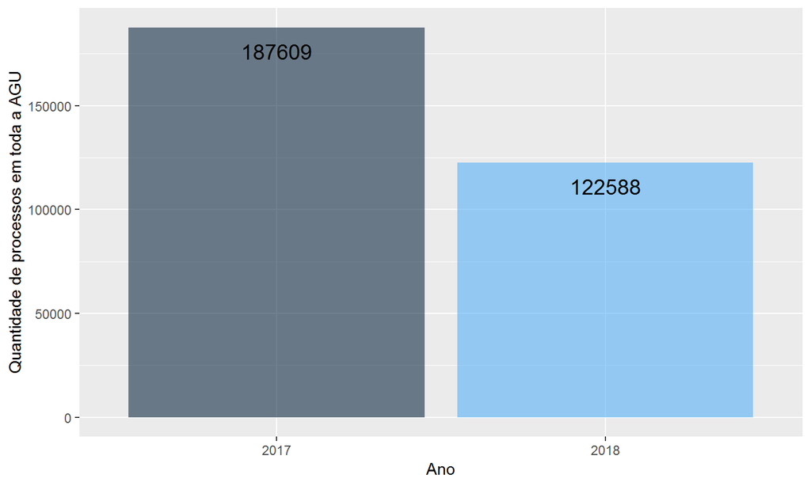

**É notável a grande quantidade, a mais, de processos em 2017.**

## Unidades com mais Processos (2017/2018)

```
## # A tibble: 6 x 5
## # Groups:   Unidade_Sigla, Unidade_Regiao [6]
##   Unidade_Sigla Unidade_Regiao `2017` `2018` total
##   <fct>         <fct>           <dbl>  <dbl> <dbl>
## 1 PRU1R         1ª Região       22062  12064 34126
## 2 PRU2R         2ª Região       15055   7564 22619
## 3 PRU4R         4ª Região       14702   9882 24584
## 4 PUPR          4ª Região       12933   8601 21534
## 5 PRU3R         3ª Região       11940   8651 20591
## 6 PRU5R         5ª Região        9664   6476 16140
```

## Regiões com mais Processos (2017/2018)

```
## # A tibble: 5 x 4
##   Unidade_Regiao api_diff_media api_diff_media_low api_diff_media_upp
##   <fct>                   <dbl>              <dbl>              <dbl>
## 1 1ª Região               5107.               846.              9367.
## 2 2ª Região               4697.               886.              8508.
## 3 3ª Região               2811.              1812.              3811.
## 4 4ª Região               3682.              2515.              4849.
## 5 5ª Região               1625.               371.              2879.
```

Para a criação dessa tabela foram consideradas as 30 unidades com mais processos no período de 2017 a 2018 (mês de outubro). Novamente, as regiões com mais processos não necessariamente são as maiores, pois podem ser as que possuem advogados mais eficientes ou, ainda, as que recebem processos mais comuns.

## Médias de processos por Região (incluindo margens de erros)

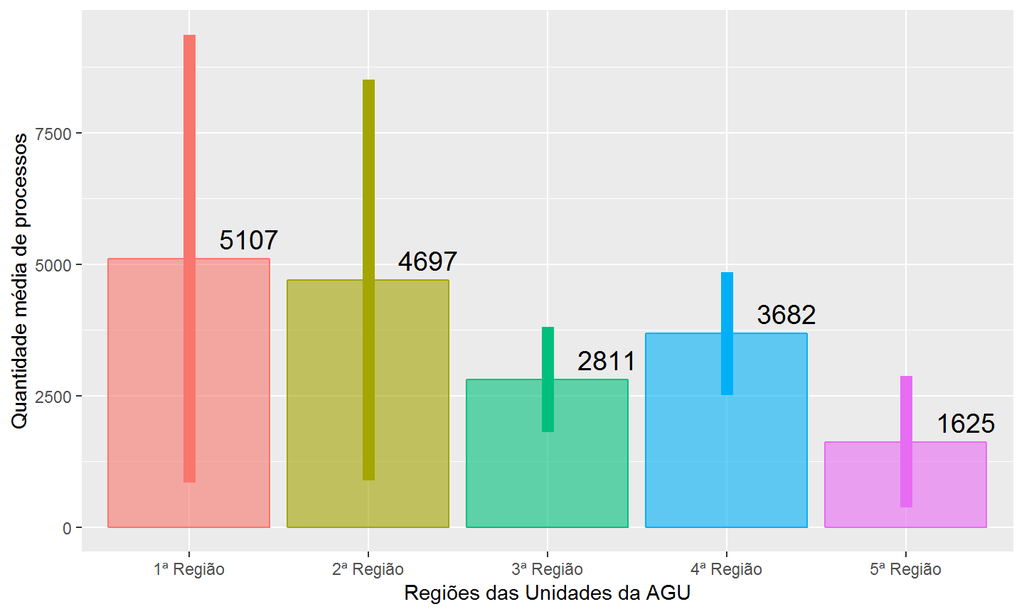

## Análise

Observa-se no gráfico apresentado que a margem de erro no cálculo da média de processos por região é muito grande para a primeira e segunda regiões, mas isso se deve ao fato de que em cada uma delas há muito mais processos finalizados em 2017.

## Quantidades de processos e usuários por Unidade

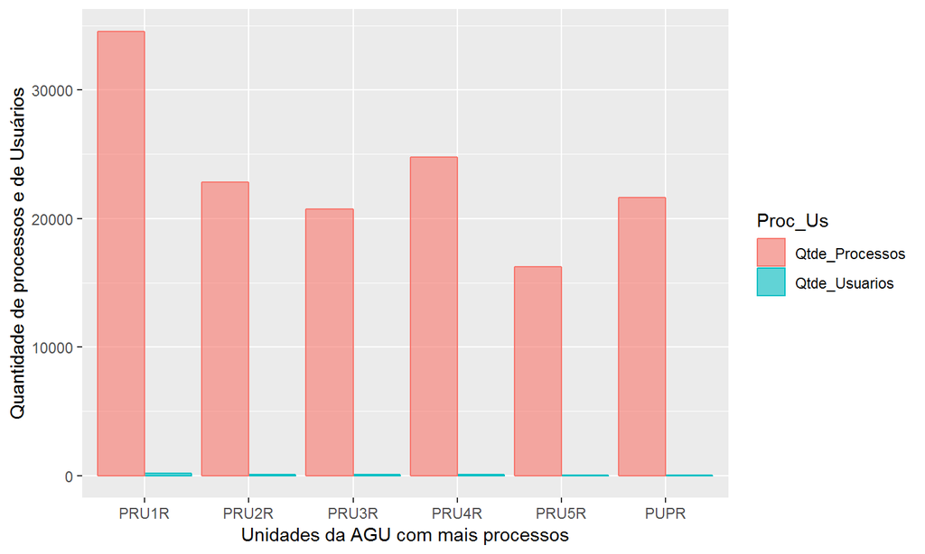

Com base no gráfico anteriormente apresentado, define-se a probabilidade de que os advogados da união e os procuradores federais na unidade PRU1R sejam muito produtivos, já que a quantidade de processos finalizados nessa unidade é muito superior à das demais unidades, mesmo sendo a quantidade de usuários um pouco maior.

Entretanto, como já foi dito, há assuntos diferentes para cada processo e graus de complexidade atribuídos a cada um destes assuntos, confirmando o caráter de probabilidades às constatações anteriormente realizadas.

## Contato: leomosqueira@gmail.com